# ST558_Homework_9_Haverhals

# Introduction

In this assignment, we will be analyzing and creating models from data in the [Seoul Bike Sharing Demand](https://archive.ics.uci.edu/dataset/560/seoul+bike+sharing+demand) data set.

## Reading the data

The first thing we’ll do is create a tibble out of provided the data.

```r
# Load the tidyverse, ggplot and save the data to a tibble
library(lubridate)
library(tidyverse)
library(ggplot2)

#Create data tibble

bike_demand<-read_csv("data/SeoulBikeData.csv",locale=locale(encoding="latin1"))
```

Note that the `locale=locale(encoding="latin1")` argument (used to fix the error mentioned in the assignment document) was found on Stack Overflow, via Google.

# EDA

## Checking the Data

### 1.

Now that we have a tibble, the next thing we’ll do is check to see if there are any missing data. To do that, we visually inspect all 8,760 rows of the tibble. Just kidding, we’ll use the `is.na()` function to check that and then sum it by column, to see how many missing values we are dealing with.

```r
# Look for missing data

colSums(is.na(bike_demand))
```

```
                     Date         Rented Bike Count                      Hour
                        0                         0                         0
          Temperature(°C)               Humidity(%)          Wind speed (m/s)
                        0                         0                         0
         Visibility (10m) Dew point temperature(°C)   Solar Radiation (MJ/m2)
                        0                         0                         0
             Rainfall(mm)             Snowfall (cm)                   Seasons
                        0                         0                         0
                  Holiday           Functioning Day
                        0                         0
```

Zero’s across the board, which is great!

### 2.

Next up, I’ll check all the columns and basic summary stats to make sure everything is making sense.

```r
# Look at raw tibble

bike_demand
```

```
# A tibble: 8,760 × 14
   Date       `Rented Bike Count`  Hour `Temperature(°C)` `Humidity(%)`
   <chr>                    <dbl> <dbl>             <dbl>         <dbl>
 1 01/12/2017                 254     0              -5.2            37
 2 01/12/2017                 204     1              -5.5            38
 3 01/12/2017                 173     2              -6              39
 4 01/12/2017                 107     3              -6.2            40
 5 01/12/2017                  78     4              -6              36
 6 01/12/2017                 100     5              -6.4            37
 7 01/12/2017                 181     6              -6.6            35
 8 01/12/2017                 460     7              -7.4            38
 9 01/12/2017                 930     8              -7.6            37
10 01/12/2017                 490     9              -6.5            27
# ℹ 8,750 more rows
# ℹ 9 more variables: `Wind speed (m/s)` <dbl>, `Visibility (10m)` <dbl>,
#   `Dew point temperature(°C)` <dbl>, `Solar Radiation (MJ/m2)` <dbl>,
#   `Rainfall(mm)` <dbl>, `Snowfall (cm)` <dbl>, Seasons <chr>, Holiday <chr>,
#   `Functioning Day` <chr>
```

Here, we see the following columns with character data: `Date`, `Seasons`, `Holiday`, and `Functioning day` and the following columns featuring numeric (double) data: `Rented Bike Count`, `Hour`, `Temperature(°C)`, `Humidity(%)`, `Wind speed (m/s)`, `Visibility (10m)`, `Dew point temperature(°C)`, `Solar Radiation (MJ/m2)`, `Rainfall(mm)`, and `Snowfall (cm)`. Of these, one might argue that `Hour` needs to should be converted because it’s a time. However, it’s useful to leave it as is because it’s measuring the time that’s elapsed since the beginning of the day.

To make sure the data themselves are reasonable, a good place to start is basic summary statistics:

```r
# verify the data pass the smell test

summary(bike_demand)
```

```
        Date      Rented Bike Count      Hour       Temperature(°C)
 Length   :8760   Min.   :   0.0    Min.   : 0.00   Min.   :-17.80
 N.unique : 365   1st Qu.: 191.0    1st Qu.: 5.75   1st Qu.:  3.50
 N.blank  :   0   Median : 504.5    Median :11.50   Median : 13.70
 Min.nchar:  10   Mean   : 704.6    Mean   :11.50   Mean   : 12.88
 Max.nchar:  10   3rd Qu.:1065.2    3rd Qu.:17.25   3rd Qu.: 22.50
                  Max.   :3556.0    Max.   :23.00   Max.   : 39.40
  Humidity(%)    Wind speed (m/s) Visibility (10m) Dew point temperature(°C)
 Min.   : 0.00   Min.   :0.000    Min.   :  27     Min.   :-30.600
 1st Qu.:42.00   1st Qu.:0.900    1st Qu.: 940     1st Qu.: -4.700
 Median :57.00   Median :1.500    Median :1698     Median :  5.100
 Mean   :58.23   Mean   :1.725    Mean   :1437     Mean   :  4.074
 3rd Qu.:74.00   3rd Qu.:2.300    3rd Qu.:2000     3rd Qu.: 14.800
 Max.   :98.00   Max.   :7.400    Max.   :2000     Max.   : 27.200
 Solar Radiation (MJ/m2)  Rainfall(mm)     Snowfall (cm)          Seasons
 Min.   :0.0000          Min.   : 0.0000   Min.   :0.00000   Length   :8760
 1st Qu.:0.0000          1st Qu.: 0.0000   1st Qu.:0.00000   N.unique :   4
 Median :0.0100          Median : 0.0000   Median :0.00000   N.blank  :   0
 Mean   :0.5691          Mean   : 0.1487   Mean   :0.07507   Min.nchar:   6
 3rd Qu.:0.9300          3rd Qu.: 0.0000   3rd Qu.:0.00000   Max.nchar:   6
 Max.   :3.5200          Max.   :35.0000   Max.   :8.80000
      Holiday      Functioning Day
 Length   :8760   Length   :8760
 N.unique :   2   N.unique :   2
 N.blank  :   0   N.blank  :   0
 Min.nchar:   7   Min.nchar:   2
 Max.nchar:  10   Max.nchar:   3
```

Looking closely at the numeric variables here, nothing stands out as unreasonable.

### 3.

Next up, we’ll use the `lubridate` package to convert our first column to an actual date. Note that the `Date` column gives day, then month, then year. Also note that the column features `/` as separators, but lubridate expects dashes.

**Note** I’ve changeed the name of the tibble at this point, so we can call the unchanged (`bike_demand`) tibble later, if necessary.

```r
# Turn first columm into date data type

demand_data<-bike_demand|>
  mutate(Date = dmy(Date))

demand_data
```

```
# A tibble: 8,760 × 14
   Date       `Rented Bike Count`  Hour `Temperature(°C)` `Humidity(%)`
   <date>                   <dbl> <dbl>             <dbl>         <dbl>
 1 2017-12-01                 254     0              -5.2            37
 2 2017-12-01                 204     1              -5.5            38
 3 2017-12-01                 173     2              -6              39
 4 2017-12-01                 107     3              -6.2            40
 5 2017-12-01                  78     4              -6              36
 6 2017-12-01                 100     5              -6.4            37
 7 2017-12-01                 181     6              -6.6            35
 8 2017-12-01                 460     7              -7.4            38
 9 2017-12-01                 930     8              -7.6            37
10 2017-12-01                 490     9              -6.5            27
# ℹ 8,750 more rows
# ℹ 9 more variables: `Wind speed (m/s)` <dbl>, `Visibility (10m)` <dbl>,
#   `Dew point temperature(°C)` <dbl>, `Solar Radiation (MJ/m2)` <dbl>,
#   `Rainfall(mm)` <dbl>, `Snowfall (cm)` <dbl>, Seasons <chr>, Holiday <chr>,
#   `Functioning Day` <chr>
```

Now, just to be sure nothing got messed up too badly:

```r
# Check for newly missing data

sum(is.na(demand_data$Date))
```

```
[1] 0
```

### 4.

Next up, we’ll turn the character variables in `Seasons`, `Holiday`, and `Functioning Day` into factors. To begin, I’d like to look at what character strings are showing up because, in particular, I’m not sure what `Functioning Day` is all about.

```r
#Retrieve observations

unique(demand_data$Seasons)
```

```
[1] "Winter" "Spring" "Summer" "Autumn"
```

```r
unique(demand_data$Holiday)
```

```
[1] "No Holiday" "Holiday"
```

```r
unique(demand_data$`Functioning Day`)
```

```
[1] "Yes" "No"
```

The strings in the first two columns make sense to me. Looking through the tibble above, I’m only seeing `Yes`, which makes me think that maybe that column is recording whether the bike being rented is functional that day. If so, it would make sense that there aren’t any `No` entries, as there wouldn’t have been a bike rented if it weren’t functioning. Let’s check to see if, in fact, there are no `No`’s.

```r
# Check to see if "No" exists

sum(demand_data$'Functioning Day' == "No")
```

```
[1] 295
```

Well, I was wrong. There are some entries where the bike wasn’t functional. Looking more closely at the information provided in the link, it says `Functional Day - NoFunc(Non Functional Hours), Fun(Functional hours)`. Maybe looking at only the entries where there is a `No` there might give a clue.

```r
#Look more closely where Functioning Day = "No"

filter(demand_data,`Functioning Day`== "No")
```

```
# A tibble: 295 × 14
   Date       `Rented Bike Count`  Hour `Temperature(°C)` `Humidity(%)`
   <date>                   <dbl> <dbl>             <dbl>         <dbl>
 1 2018-04-11                   0     0              14.4            82
 2 2018-04-11                   0     1              13.6            81
 3 2018-04-11                   0     2              12.7            80
 4 2018-04-11                   0     3              11.6            81
 5 2018-04-11                   0     4              10.2            83
 6 2018-04-11                   0     5               9.7            84
 7 2018-04-11                   0     6               9              86
 8 2018-04-11                   0     7               8.8            85
 9 2018-04-11                   0     8               9.7            77
10 2018-04-11                   0     9              11.8            59
# ℹ 285 more rows
# ℹ 9 more variables: `Wind speed (m/s)` <dbl>, `Visibility (10m)` <dbl>,
#   `Dew point temperature(°C)` <dbl>, `Solar Radiation (MJ/m2)` <dbl>,
#   `Rainfall(mm)` <dbl>, `Snowfall (cm)` <dbl>, Seasons <chr>, Holiday <chr>,
#   `Functioning Day` <chr>
```

So, it’s looking like there weren’t any rentals when we had a `No` there. To confirm:

```r
# Confirm no rentals when Functioning Day = "No"

filter(demand_data,`Functioning Day`== "No") |> pull(`Rented Bike Count`)|>sum()
```

```
[1] 0
```

So, it’s looking like that column is registering times when someone went to rent a bike, but the bike wasn’t functioning (and so nothing was rented).

With that in mind, we’ll next finish what we set out to do in this problem: create factors.

```r
# Create levels as appropriate

demand_data <- mutate(demand_data,
  SeasonsF = factor(Seasons, levels = c("Winter", "Spring", "Summer", "Autumn")),
  HolidayF = factor(Holiday, levels = c("No Holiday", "Holiday")),
  FunctioningF = factor(`Functioning Day`, levels = c("Yes", "No"))
)

demand_data
```

```
# A tibble: 8,760 × 17
   Date       `Rented Bike Count`  Hour `Temperature(°C)` `Humidity(%)`
   <date>                   <dbl> <dbl>             <dbl>         <dbl>
 1 2017-12-01                 254     0              -5.2            37
 2 2017-12-01                 204     1              -5.5            38
 3 2017-12-01                 173     2              -6              39
 4 2017-12-01                 107     3              -6.2            40
 5 2017-12-01                  78     4              -6              36
 6 2017-12-01                 100     5              -6.4            37
 7 2017-12-01                 181     6              -6.6            35
 8 2017-12-01                 460     7              -7.4            38
 9 2017-12-01                 930     8              -7.6            37
10 2017-12-01                 490     9              -6.5            27
# ℹ 8,750 more rows
# ℹ 12 more variables: `Wind speed (m/s)` <dbl>, `Visibility (10m)` <dbl>,
#   `Dew point temperature(°C)` <dbl>, `Solar Radiation (MJ/m2)` <dbl>,
#   `Rainfall(mm)` <dbl>, `Snowfall (cm)` <dbl>, Seasons <chr>, Holiday <chr>,
#   `Functioning Day` <chr>, SeasonsF <fct>, HolidayF <fct>, FunctioningF <fct>
```

### 5.

Next up, we’ll rename the columns so they’re a bit friendlier (and all lower case). Note that I’ll rename the factorized columns with lower case (sans `F`) for simplicity and tack on `_old` to the columns we no longer want to use.

```r
# Rename columns

demand_data <- demand_data |>
  rename(
    date = 1,
    bike_count = 2,
    hour = 3,
    temp = 4,
    humidity = 5,
    wind_speed = 6,
    visibility = 7,
    dew_pt = 8,
    solar_rad = 9,
    rainfall = 10,
    snowfall = 11,
    Seasons_old = 12,
    Holiday_old = 13,
    Functioning_old = 14,
    seasons = 15,
    holiday = 16,
    functioning = 17
  )

demand_data
```

```
# A tibble: 8,760 × 17
   date       bike_count  hour  temp humidity wind_speed visibility dew_pt
   <date>          <dbl> <dbl> <dbl>    <dbl>      <dbl>      <dbl>  <dbl>
 1 2017-12-01        254     0  -5.2       37        2.2       2000  -17.6
 2 2017-12-01        204     1  -5.5       38        0.8       2000  -17.6
 3 2017-12-01        173     2  -6         39        1         2000  -17.7
 4 2017-12-01        107     3  -6.2       40        0.9       2000  -17.6
 5 2017-12-01         78     4  -6         36        2.3       2000  -18.6
 6 2017-12-01        100     5  -6.4       37        1.5       2000  -18.7
 7 2017-12-01        181     6  -6.6       35        1.3       2000  -19.5
 8 2017-12-01        460     7  -7.4       38        0.9       2000  -19.3
 9 2017-12-01        930     8  -7.6       37        1.1       2000  -19.8
10 2017-12-01        490     9  -6.5       27        0.5       1928  -22.4
# ℹ 8,750 more rows
# ℹ 9 more variables: solar_rad <dbl>, rainfall <dbl>, snowfall <dbl>,
#   Seasons_old <chr>, Holiday_old <chr>, Functioning_old <chr>, seasons <fct>,
#   holiday <fct>, functioning <fct>
```

### 6.

For this part, we’ll create summary tables. To being, we’ll do a basic summary across the numeric variables. Recall that, earlier, we noticed that the tibble records whether the bike was functioning. So, in the summary below, I’m going to subset on times when the bike was functioning.

```r
# Five +1 number summaries across numeric data

six_num_sum <- apply(X = demand_data |>
                       filter(functioning == "Yes")|>
                        select(where(is.numeric)),
                      MARGIN = 2,
                      FUN = summary
                      )
six_num_sum
```

```
        bike_count     hour      temp humidity wind_speed visibility     dew_pt
Min.         2.000  0.00000 -17.80000  0.00000   0.000000     27.000 -30.600000
1st Qu.    214.000  6.00000   3.00000 42.00000   0.900000    935.000  -5.100000
Median     542.000 12.00000  13.50000 57.00000   1.500000   1690.000   4.700000
Mean       729.157 11.50703  12.77106 58.14719   1.725883   1433.873   3.944997
3rd Qu.   1084.000 18.00000  22.70000 74.00000   2.300000   2000.000  15.200000
Max.      3556.000 23.00000  39.40000 98.00000   7.400000   2000.000  27.200000
        solar_rad   rainfall   snowfall
Min.    0.0000000  0.0000000 0.00000000
1st Qu. 0.0000000  0.0000000 0.00000000
Median  0.0100000  0.0000000 0.00000000
Mean    0.5678677  0.1491199 0.07768458
3rd Qu. 0.9300000  0.0000000 0.00000000
Max.    3.5200000 35.0000000 8.80000000
```

Next up, let’s look at some one way tables based on categorical variables.

```r
# One way tables
one_way <- list(
  seasons_summary = demand_data |> group_by(seasons) |> summarize(count = n()),
  holiday_summary = demand_data |> group_by(holiday) |> summarize(count = n()),
  functioning_summary = demand_data |> group_by(functioning) |> summarize(count = n())
)

one_way
```

```
$seasons_summary
# A tibble: 4 × 2
  seasons count
  <fct>   <int>
1 Winter   2160
2 Spring   2208
3 Summer   2208
4 Autumn   2184

$holiday_summary
# A tibble: 2 × 2
  holiday    count
  <fct>      <int>
1 No Holiday  8328
2 Holiday      432

$functioning_summary
# A tibble: 2 × 2
  functioning count
  <fct>       <int>
1 Yes          8465
2 No            295
```

Next, we compare bike rental counts between functioning and nonfunctioning hours. This helps us decide which observations to retain for our analysis.

```r
# Summarize hourly rentals by functioning status
demand_data |>
  group_by(functioning) |>
  summarize(
    hours = n(),
    mean_rentals = mean(bike_count),
    median_rentals = median(bike_count),
    sd_rentals = sd(bike_count),
    min_rentals = min(bike_count),
    max_rentals = max(bike_count)
  )
```

```
# A tibble: 2 × 7
  functioning hours mean_rentals median_rentals sd_rentals min_rentals
  <fct>       <int>        <dbl>          <dbl>      <dbl>       <dbl>
1 Yes          8465         729.            542       642.           2
2 No            295           0               0         0            0
# ℹ 1 more variable: max_rentals <dbl>
```

Nonfunctioning hours have zero recorded rentals. We exclude these hours so that the remaining analysis describes bike rental demand while the service was functioning.

```r
# Retain functioning hours for the remaining analysis
demand_data <- demand_data |>
  filter(functioning == "Yes")

# Check the number of retained rows
nrow(demand_data)
```

```
[1] 8465
```

Using the functioning hours, we next compare hourly bike rental counts across seasons.

```r
# Summarize hourly rentals within each season
demand_data |>
  group_by(seasons) |>
  summarize(
    hours = n(),
    mean_rentals = mean(bike_count),
    median_rentals = median(bike_count),
    sd_rentals = sd(bike_count),
    min_rentals = min(bike_count),
    max_rentals = max(bike_count)
  )
```

```
# A tibble: 4 × 7
  seasons hours mean_rentals median_rentals sd_rentals min_rentals max_rentals
  <fct>   <int>        <dbl>          <dbl>      <dbl>       <dbl>       <dbl>
1 Winter   2160         226.           203        150.           3         937
2 Spring   2160         746.           599        619.           2        3251
3 Summer   2208        1034.           906.       690.           9        3556
4 Autumn   1937         924.           856        618.           2        3298
```

Summer had the highest average hourly bike rental count, at approximately 1,034 rentals, followed by autumn at 924 and spring at 746. Winter had the lowest average, at approximately 226 rentals per hour. The medians followed the same seasonal pattern. Hourly rental counts also varied more in summer, which had the largest standard deviation at approximately 690 rentals, compared with approximately 150 in winter. These summaries suggest that rental demand differs across seasons, although they do not account for other factors such as weather.

We also compare hourly rental counts between holidays and nonholidays.

```r
# Summarize hourly rentals by holiday status
demand_data |>
  group_by(holiday) |>
  summarize(
    hours = n(),
    mean_rentals = mean(bike_count),
    median_rentals = median(bike_count),
    sd_rentals = sd(bike_count),
    min_rentals = min(bike_count),
    max_rentals = max(bike_count)
  )
```

```
# A tibble: 2 × 7
  holiday   hours mean_rentals median_rentals sd_rentals min_rentals max_rentals
  <fct>     <int>        <dbl>          <dbl>      <dbl>       <dbl>       <dbl>
1 No Holid…  8057         739.            561       644.           2        3556
2 Holiday     408         529.            259       574.           3        2400
```

Nonholidays had a higher average hourly rental count than holidays: approximately 739 versus 529 rentals. The median was also higher on nonholidays, at 561 compared with 259 on holidays. Rental counts showed somewhat greater variability on nonholidays, with a standard deviation of approximately 644 compared with 574 on holidays. We compare averages rather than total rentals because the dataset contains many more functioning hours on nonholidays than on holidays. These are descriptive comparisons and do not establish that holiday status causes the difference in rental demand.

So far, each observation represents one functioning hour. Next, we will summarize the data by date, season, and holiday status so that each retained day has one observation for the remaining analysis.

### 7.

Next, we combine the hourly observations into daily summaries. We group by date, season, and holiday status, then calculate daily totals for bike rentals, rainfall, and snowfall. For the remaining weather variables, we calculate daily averages. These summaries use the functioning hours retained in the previous step.

```r
# Combine the retained hourly observations into daily summaries
daily_demand <- demand_data |>
  group_by(date, seasons, holiday) |>
  summarize(
    bike_count = sum(bike_count),
    rainfall = sum(rainfall),
    snowfall = sum(snowfall),
    temp = mean(temp),
    humidity = mean(humidity),
    wind_speed = mean(wind_speed),
    visibility = mean(visibility),
    dew_pt = mean(dew_pt),
    solar_rad = mean(solar_rad),
    .groups = "drop"
  )

# View the daily dataset
daily_demand
```

```
# A tibble: 353 × 12
   date       seasons holiday    bike_count rainfall snowfall    temp humidity
   <date>     <fct>   <fct>           <dbl>    <dbl>    <dbl>   <dbl>    <dbl>
 1 2017-12-01 Winter  No Holiday       9539      0        0   -2.45       45.9
 2 2017-12-02 Winter  No Holiday       8523      0        0    1.33       62.0
 3 2017-12-03 Winter  No Holiday       7222      4        0    4.88       81.5
 4 2017-12-04 Winter  No Holiday       8729      0.1      0   -0.304      52.5
 5 2017-12-05 Winter  No Holiday       8307      0        0   -4.46       36.4
 6 2017-12-06 Winter  No Holiday       6669      1.3      8.6  0.0458     70.8
 7 2017-12-07 Winter  No Holiday       8549      0       10.4  1.09       67.5
 8 2017-12-08 Winter  No Holiday       8032      0        0   -3.82       41.8
 9 2017-12-09 Winter  No Holiday       7233      0        0   -0.846      46
10 2017-12-10 Winter  No Holiday       3453      4.1     32.5  1.19       69.7
# ℹ 343 more rows
# ℹ 4 more variables: wind_speed <dbl>, visibility <dbl>, dew_pt <dbl>,
#   solar_rad <dbl>
```

### 8.

Now that the data have been summarized by day, we revisit the numerical summaries. The bike rental count now represents the total rentals during each day’s retained functioning hours. Rainfall and snowfall are summed across those hours, while the other weather variables represent averages.

```r
# Summarize the numeric variables in the daily dataset
daily_summary <- apply(
  X = daily_demand |>
    select(where(is.numeric)),
  MARGIN = 2,
  FUN = summary
)

daily_summary
```

```
        bike_count  rainfall snowfall       temp humidity wind_speed visibility
Min.        977.00  0.000000  0.00000 -14.737500 22.25000   0.662500   214.2917
1st Qu.    6967.00  0.000000  0.00000   3.304167 47.58333   1.304167  1087.0417
Median    18563.00  0.000000  0.00000  13.737500 57.16667   1.658333  1557.7500
Mean      17485.31  3.575921  1.86289  12.775844 58.16627   1.726148  1434.0137
3rd Qu.   26285.00  0.500000  0.00000  22.591667 67.70833   1.954167  1874.2917
Max.      36149.00 95.500000 78.70000  33.741667 95.87500   4.000000  2000.0000
            dew_pt  solar_rad
Min.    -27.750000 0.02916667
1st Qu.  -5.187500 0.28333333
Median    4.612500 0.56500000
Mean      3.954165 0.56773191
3rd Qu.  14.920833 0.82000000
Max.     25.037500 1.21666667
```

Daily bike rental totals ranged from 977 to 36,149, with an average of approximately 17,485 and a median of 18,563. The middle 50% of daily totals fell between 6,967 and 26,285, showing substantial variation across days. Average daily temperature also varied considerably, ranging from approximately −14.7°C to 33.7°C. Rainfall and snowfall summaries contained many zeros, indicating that precipitation was absent on many of the retained days.

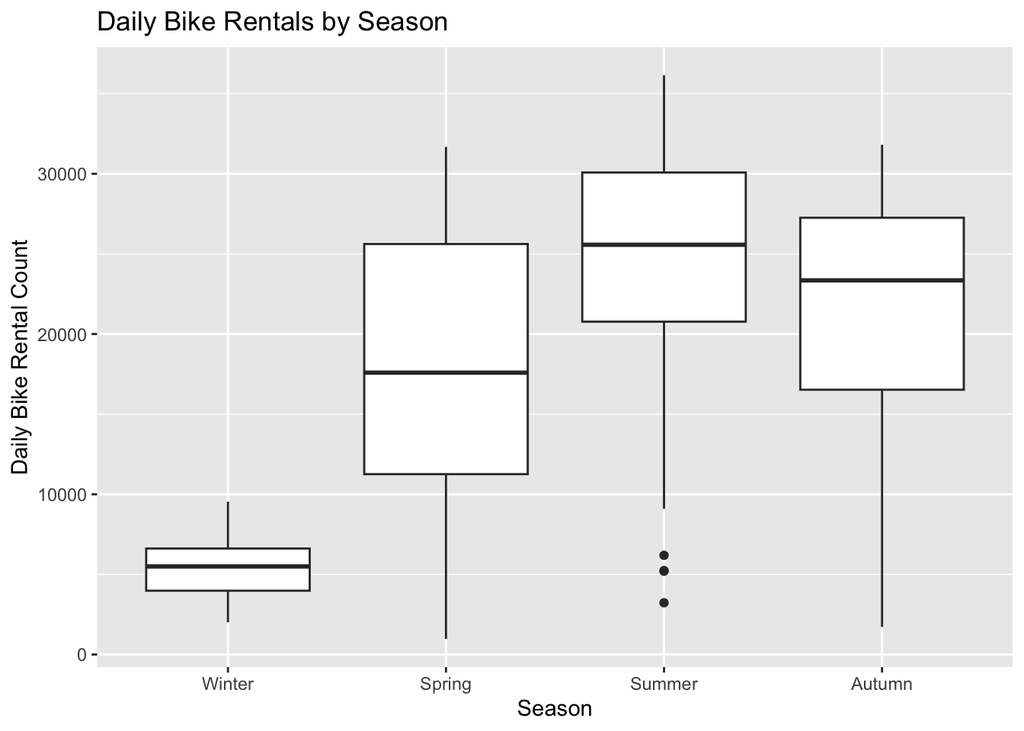

```r
# Compare the distribution of daily rentals across seasons
ggplot(
  data = daily_demand,
  mapping = aes(x = seasons, y = bike_count)
) +
  geom_boxplot() +
  labs(
    title = "Daily Bike Rentals by Season",
    x = "Season",
    y = "Daily Bike Rental Count"
  )
```

Daily bike rental counts differed across seasons. Summer had the highest median daily rental count, followed by autumn, spring, and winter. Winter also had the smallest spread in the middle 50% of daily counts, while spring had the largest. Summer had three unusually low daily totals, shown as points below the lower whisker. These observations may warrant closer examination, but the plot alone does not establish why they were low.

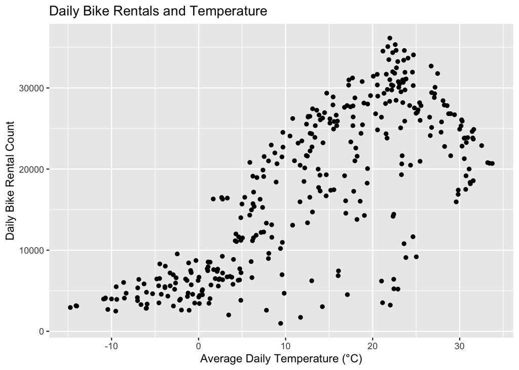

```r
# Explore daily rentals in relation to average temperature
ggplot(
  data = daily_demand,
  mapping = aes(x = temp, y = bike_count)
) +
  geom_point() +
  labs(
    title = "Daily Bike Rentals and Temperature",
    x = "Average Daily Temperature (°C)",
    y = "Daily Bike Rental Count"
  )
```

Daily bike rentals generally increased with average daily temperature, although the relationship appears curved rather than perfectly straight. Rental counts were generally highest around 20–25°C and tended to decrease at higher temperatures. There was also considerable variation among days with similar temperatures, suggesting that temperature alone does not explain daily rental demand.

Next, we examine correlations among the daily numeric variables. These describe the direction and strength of pairwise linear relationships, including relationships between bike rental counts and weather variables. We also examine correlations among the weather variables because some predictors may contain similar information.

```r
# Select the numeric variables from the daily dataset
daily_numeric <- daily_demand |>
  select(where(is.numeric))

# Calculate Pearson correlations
daily_correlations <- cor(daily_numeric)

# Display correlations rounded to two decimal places
round(daily_correlations, digits = 2)
```

```
           bike_count rainfall snowfall  temp humidity wind_speed visibility
bike_count       1.00    -0.24    -0.27  0.75     0.04      -0.19       0.17
rainfall        -0.24     1.00    -0.02  0.14     0.53      -0.10      -0.22
snowfall        -0.27    -0.02     1.00 -0.27     0.07       0.02      -0.10
temp             0.75     0.14    -0.27  1.00     0.40      -0.26       0.00
humidity         0.04     0.53     0.07  0.40     1.00      -0.23      -0.56
wind_speed      -0.19    -0.10     0.02 -0.26    -0.23       1.00       0.21
visibility       0.17    -0.22    -0.10  0.00    -0.56       0.21       1.00
dew_pt           0.65     0.26    -0.21  0.96     0.63      -0.29      -0.15
solar_rad        0.74    -0.32    -0.23  0.55    -0.27       0.10       0.27
           dew_pt solar_rad
bike_count   0.65      0.74
rainfall     0.26     -0.32
snowfall    -0.21     -0.23
temp         0.96      0.55
humidity     0.63     -0.27
wind_speed  -0.29      0.10
visibility  -0.15      0.27
dew_pt       1.00      0.38
solar_rad    0.38      1.00
```

Daily bike rental counts had positive correlations with temperature (0.75), solar radiation (0.74), and dew point temperature (0.65). Correlations with rainfall (−0.24) and snowfall (−0.27) were negative but weaker. Humidity had little linear association with rental counts (0.04), although this does not rule out a curved relationship or an association after accounting for other variables. Temperature and dew point were very strongly correlated (0.96), suggesting that these predictors contain overlapping information. Including both in a regression model may make their individual coefficients harder to interpret.

# Split the Data

We next randomly divide the daily data into approximately 75% training data and 25% test data. We stratify the split by season so that each season is represented in roughly similar proportions in both sets. The training data will be used to fit the models, and the test data will be used to compare their prediction errors. We set a random seed so that the split can be reproduced.

```r
# Make the random split reproducible
set.seed(558)

# Split the daily data, sampling within each season
bike_split <- rsample::initial_split(
  daily_demand,
  prop = 0.75,
  strata = seasons
)

# Extract the training and test datasets
bike_train <- rsample::training(bike_split)
bike_test <- rsample::testing(bike_split)

# Check the number of days in each dataset
nrow(bike_train)
```

```
[1] 263
```

```r
nrow(bike_test)
```

```
[1] 90
```

```r
# Check seasonal representation
table(bike_train$seasons)
```

```
Winter Spring Summer Autumn
    67     67     69     60
```

```r
table(bike_test$seasons)
```

```
Winter Spring Summer Autumn
    23     23     23     21
```

The split produced 263 training observations and 90 test observations. Each season is represented in both datasets, with approximately three-quarters of its days assigned to training and the remainder assigned to testing.

# Fitting Multiple Linear Regression Models

We will use multiple linear regression to predict daily bike rental counts from weather and calendar variables. Before fitting the models, we will use the date to create a weekday/weekend factor in both datasets, then exclude the date itself as a predictor. We will also standardize the numeric weather predictors by subtracting their training-set means and dividing by their training-set standard deviations. The test predictors will be standardized using those same training-set values.

We will compare three models: one containing the specified weather and calendar predictors, a second adding the specified interactions, and a third adding squared temperature and humidity terms. Each model will be fitted using the training data and evaluated using test-set root mean squared error (RMSE), where a smaller value indicates lower prediction error. Following the assignment instructions, we will then refit the model with the lowest test RMSE using the full daily dataset and report its coefficients.